# Tarea 2 - 2022 2do Semestre

## Introducción al Machine Learning

## Consideraciones en la entrega

- La tarea debe ser enviada en forma de script, por ejemplo `mi_archivo.R`.
- Al comienzo del script deben identificarse los integrandes del grupo, máximo 3.
- El script debe generar, en orden, los resultados solicitados. Agregando en forma de comentarios (`los comentarios parten con #`) cualquier respuesta o información adicional que se requiera.
- El script debe ser reproducible. El archivo .R debe poder ejecutarse sin problemas por cualquier persona con el programa, siguiendo el orden lógico requerido para ello.
- La fecha de entrega es domingo 13 noviembre 2022. Por día se baja un punto.

## Datos a utilizar

Los datos a utilizar corresponde a registros históricos de dos años (2011 y 2012) del sistema “Capital Bikeshare”, en Washington D.C. Existen dos versiones de estos datos: (1) agrupados por hora y (2) por día; los cuales encontrará en [repositorio](https://github.com/jbkunst/intro-machine-learning/tree/main/data) como `bike_hour.csv` y `bike_day.csv`.

El proceso de alquiler de bicicletas compartidas está altamente correlacionado con los entornos ambientales y estacionales. La precipitación, el día de la semana, la estación, la hora del día, etc. pueden afectar los comportamientos de alquiler.

La variable de interés es `cnt` que contiene las bicicletas rentadas en cada observación.

```r
library(tidyverse)
bicihora <- read_csv("https://raw.githubusercontent.com/jbkunst/intro-machine-learning/main/data/bike_hour.csv")
glimpse(bicihora)
```

```
## Rows: 17,379
## Columns: 17
## $ instant    <dbl> 1, 2, 3, 4, 5, 6, 7, 8, 9, 10, 11, 12, 13, 14, 15, 16, 17, …
## $ dteday     <date> 2011-01-01, 2011-01-01, 2011-01-01, 2011-01-01, 2011-01-01…
## $ season     <dbl> 1, 1, 1, 1, 1, 1, 1, 1, 1, 1, 1, 1, 1, 1, 1, 1, 1, 1, 1, 1,…
## $ yr         <dbl> 0, 0, 0, 0, 0, 0, 0, 0, 0, 0, 0, 0, 0, 0, 0, 0, 0, 0, 0, 0,…
## $ mnth       <dbl> 1, 1, 1, 1, 1, 1, 1, 1, 1, 1, 1, 1, 1, 1, 1, 1, 1, 1, 1, 1,…
## $ hr         <dbl> 0, 1, 2, 3, 4, 5, 6, 7, 8, 9, 10, 11, 12, 13, 14, 15, 16, 1…
## $ holiday    <dbl> 0, 0, 0, 0, 0, 0, 0, 0, 0, 0, 0, 0, 0, 0, 0, 0, 0, 0, 0, 0,…
## $ weekday    <dbl> 6, 6, 6, 6, 6, 6, 6, 6, 6, 6, 6, 6, 6, 6, 6, 6, 6, 6, 6, 6,…
## $ workingday <dbl> 0, 0, 0, 0, 0, 0, 0, 0, 0, 0, 0, 0, 0, 0, 0, 0, 0, 0, 0, 0,…
## $ weathersit <dbl> 1, 1, 1, 1, 1, 2, 1, 1, 1, 1, 1, 1, 1, 2, 2, 2, 2, 2, 3, 3,…
## $ temp       <dbl> 0.24, 0.22, 0.22, 0.24, 0.24, 0.24, 0.22, 0.20, 0.24, 0.32,…
## $ atemp      <dbl> 0.2879, 0.2727, 0.2727, 0.2879, 0.2879, 0.2576, 0.2727, 0.2…
## $ hum        <dbl> 0.81, 0.80, 0.80, 0.75, 0.75, 0.75, 0.80, 0.86, 0.75, 0.76,…
## $ windspeed  <dbl> 0.0000, 0.0000, 0.0000, 0.0000, 0.0000, 0.0896, 0.0000, 0.0…
## $ casual     <dbl> 3, 8, 5, 3, 0, 0, 2, 1, 1, 8, 12, 26, 29, 47, 35, 40, 41, 1…
## $ registered <dbl> 13, 32, 27, 10, 1, 1, 0, 2, 7, 6, 24, 30, 55, 47, 71, 70, 5…
## $ cnt        <dbl> 16, 40, 32, 13, 1, 1, 2, 3, 8, 14, 36, 56, 84, 94, 106, 110…
```

Al final del documento encontrará un anexo con las definiciones de las variables.

# Preguntas

Todas las preguntas valen 1 punto exceptuando los casos en que se indique lo contrario.

1. ¿Qué columnas le hacen sentido serán las más importantes en el proceso de crear en un modelo para predecir cuántas bicicletas serán arrendadas en un día? ¿Por qué?

```r
# el clima dado que si llueve es muy problame... argumento!
#
```

1. Elimine las columnas `casual` y `registered` de los datos.

```r
bicihora <- bicihora |>
  select(-casual, -registered)
```

1. Realice un diagrama de dispersión entre las variables `dteday` y la variable `cnt`. ¿Qué observa?

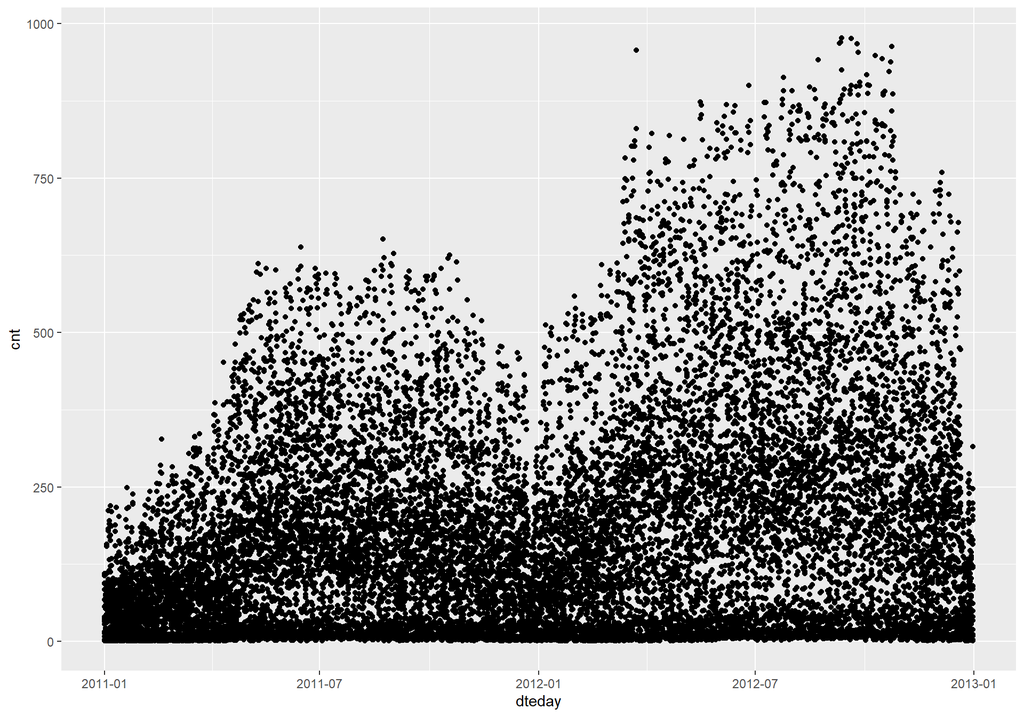

```r
ggplot(bicihora) +
  geom_point(aes(dteday, cnt))
```

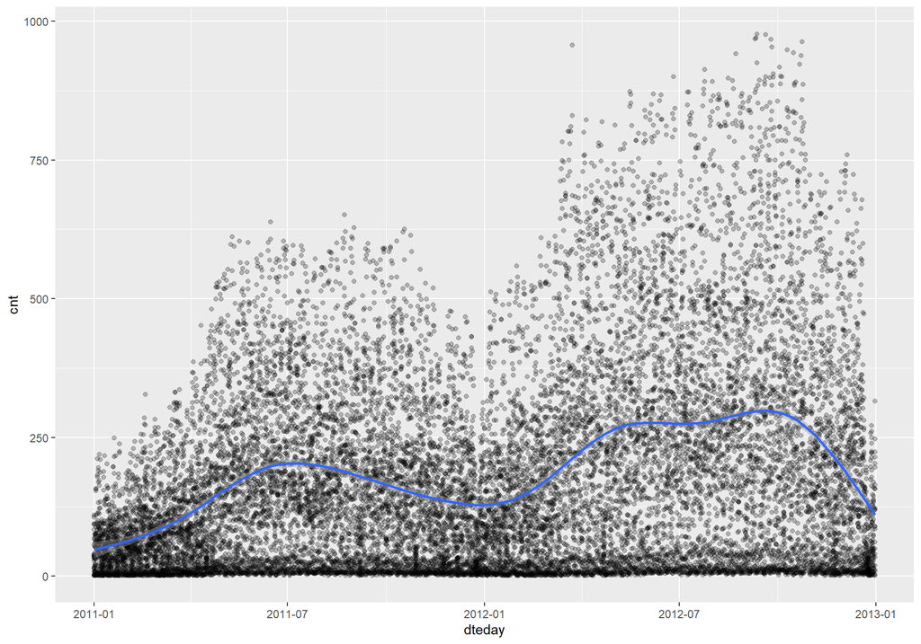

```r
# un diagram de puntos: se ve una diferencia entre temporadas, estaciones del año.
#
# Una mejora sería:
ggplot(bicihora, aes(dteday, cnt)) +
  geom_point(alpha = 0.25) +
  geom_smooth()
```

1. Cree dos tablas a partir de `bicihora`: Una para utilizarla como muestra de entrenamiento considerando todos los registros previos (no inclusive) al primero de julio del 2012, y el complemento como muestra de validación. (hint: utilice la funcion `ymd` del paquete lubridate, por ejemplo `ymd(20220101)`.

```r
library(lubridate)

bicihora_train <- bicihora |>
  filter(dteday < ymd(20120701))

bicihora_test <- bicihora |>
  filter(dteday >= ymd(20120701))
```

1. En clases se conversó que la muestra de entrenamiento/validación tenía que obtenerse de forma aleatoria, en este caso -pregunta anterior- se realiza de manera determinística. ¿Por qué podría tener sentido realizarlo de esta forma?

```r
# Dado que es de interés precedir la demanda a futuro, la idea es simular/evaluar
# la calidad predictiva para datos más nuevos: derecho del gráfico.
```

1. Ajuste un árbol con la función `ctree` y con profundidad 5. Comenté el árbol obtenido y obtenga el error cuadrático medio (*M**S**E*) tanto en la muestra de entrenamiento y validación.

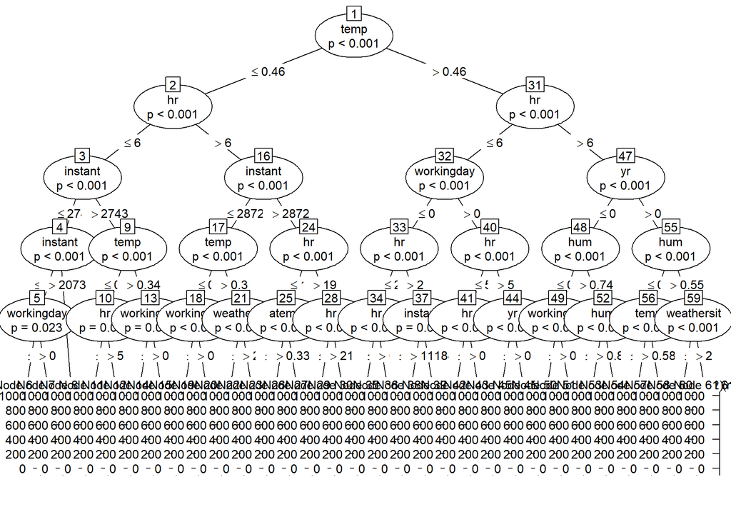

```r
library(partykit)

modtree <- ctree(cnt ~ .,
                 data = bicihora_train |> select(-dteday),
                 control = ctree_control(maxdepth = 5)
                 )

plot(modtree)
```

```r
# Se observa que la variable más importante es la temperatura y la hora.

bicihora_train |>
  mutate(ypred = predict(modtree, newdata = bicihora_train)) |>
  summarise(mean((cnt - ypred)^2))
```

```
## # A tibble: 1 × 1
##   `mean((cnt - ypred)^2)`
##                     <dbl>
## 1                  11118.
```

```r
bicihora_test |>
  mutate(ypred = predict(modtree, newdata = bicihora_test)) |>
  summarise(mean((cnt - ypred)^2))
```

```
## # A tibble: 1 × 1
##   `mean((cnt - ypred)^2)`
##                     <dbl>
## 1                  25877.
```

1. (2 puntos) Ajuste un modelo de random forest en la muestra de entrenamiento. Luego genere la prediccion de la cantidad de bicicletas arrenadas por *día* en la muestra de validación, mencionando el *M**S**E* a nivel día.

```r
library(randomForest)

modrf <- randomForest(cnt ~ .,
                      data = bicihora_train |> select(-dteday),
                      do.trace = FALSE,
                      ntree = 200
                      )
```

El modelo se ajustó con datos **horarios** Por lo que para obtener el error a nivel día se debe: - Obtener las predicciones a nivel horario. - Agrupar por dia obteniendo el conteo real diario `sum(cnt)` y las predicciones a nivel diario `sum(ypred)` - Con lo anterior existe un valor real diario y una estimación diaria por lo que se puede obtener el *M**S**E* a nivel dia.

```r
bicihora_train |>
  mutate(ypred = predict(modrf, newdata = bicihora_train)) |>
  group_by(dteday) |>
  summarise(cnt = sum(cnt), ypred = sum(ypred)) |>
  summarise(mean((cnt - ypred)^2))
```

```
## # A tibble: 1 × 1
##   `mean((cnt - ypred)^2)`
##                     <dbl>
## 1                  17792.
```

```r
bicihora_test |>
  mutate(ypred = predict(modrf, newdata = bicihora_test)) |>
  group_by(dteday) |>
  summarise(cnt = sum(cnt), ypred = sum(ypred)) |>
  summarise(mean((cnt - ypred)^2))
```

```
## # A tibble: 1 × 1
##   `mean((cnt - ypred)^2)`
##                     <dbl>
## 1                1317014.
```

1. (2 puntos) Repita el ejercicio anterior pero con los datos ya diarios `bike_day.csv`. ¿Con que metodología se obtiene mejores resultados en términos de *M**S**E*? ¿Era de esperar dichos resultados?

```r
bicidia <- read_csv("https://raw.githubusercontent.com/jbkunst/intro-machine-learning/main/data/bike_day.csv")
glimpse(bicidia)
```

```
## Rows: 731
## Columns: 16
## $ instant    <dbl> 1, 2, 3, 4, 5, 6, 7, 8, 9, 10, 11, 12, 13, 14, 15, 16, 17, …
## $ dteday     <date> 2011-01-01, 2011-01-02, 2011-01-03, 2011-01-04, 2011-01-05…
## $ season     <dbl> 1, 1, 1, 1, 1, 1, 1, 1, 1, 1, 1, 1, 1, 1, 1, 1, 1, 1, 1, 1,…
## $ yr         <dbl> 0, 0, 0, 0, 0, 0, 0, 0, 0, 0, 0, 0, 0, 0, 0, 0, 0, 0, 0, 0,…
## $ mnth       <dbl> 1, 1, 1, 1, 1, 1, 1, 1, 1, 1, 1, 1, 1, 1, 1, 1, 1, 1, 1, 1,…
## $ holiday    <dbl> 0, 0, 0, 0, 0, 0, 0, 0, 0, 0, 0, 0, 0, 0, 0, 0, 1, 0, 0, 0,…
## $ weekday    <dbl> 6, 0, 1, 2, 3, 4, 5, 6, 0, 1, 2, 3, 4, 5, 6, 0, 1, 2, 3, 4,…
## $ workingday <dbl> 0, 0, 1, 1, 1, 1, 1, 0, 0, 1, 1, 1, 1, 1, 0, 0, 0, 1, 1, 1,…
## $ weathersit <dbl> 2, 2, 1, 1, 1, 1, 2, 2, 1, 1, 2, 1, 1, 1, 2, 1, 2, 2, 2, 2,…
## $ temp       <dbl> 0.3441670, 0.3634780, 0.1963640, 0.2000000, 0.2269570, 0.20…
## $ atemp      <dbl> 0.3636250, 0.3537390, 0.1894050, 0.2121220, 0.2292700, 0.23…
## $ hum        <dbl> 0.805833, 0.696087, 0.437273, 0.590435, 0.436957, 0.518261,…
## $ windspeed  <dbl> 0.1604460, 0.2485390, 0.2483090, 0.1602960, 0.1869000, 0.08…
## $ casual     <dbl> 331, 131, 120, 108, 82, 88, 148, 68, 54, 41, 43, 25, 38, 54…
## $ registered <dbl> 654, 670, 1229, 1454, 1518, 1518, 1362, 891, 768, 1280, 122…
## $ cnt        <dbl> 985, 801, 1349, 1562, 1600, 1606, 1510, 959, 822, 1321, 126…
```

```r
bicidia <- bicidia |>
  select(-casual, -registered)

bicidia_train <- bicidia |>
  filter(dteday < ymd(20120701))

bicidia_test <- bicidia |>
  filter(dteday >= ymd(20120701))

modrfdia <- randomForest(cnt ~ .,
                         data = bicidia_train |> select(-dteday),
                         do.trace = FALSE,
                         ntree = 200
                         )

bicidia_train |>
  mutate(ypred = predict(modrfdia, newdata = bicidia_train)) |>
  summarise(mean((cnt - ypred)^2))
```

```
## # A tibble: 1 × 1
##   `mean((cnt - ypred)^2)`
##                     <dbl>
## 1                  70385.
```

```r
bicidia_test |>
  mutate(ypred = predict(modrfdia, newdata = bicidia_test)) |>
  summarise(mean((cnt - ypred)^2))
```

```
## # A tibble: 1 × 1
##   `mean((cnt - ypred)^2)`
##                     <dbl>
## 1                1529338.
```

Son similares a lo obtenido con el modelo *horarios* agrupado a *diarios*. El modelo horario presenta menor error dado que se utilizó mayor detalle en la información lo que pudo generar esa ganacia en términos predictivos.

## Anexo

Definción y detalles de las variables:

- instant: record index
- dteday : date
- season : season (1:springer, 2:summer, 3:fall, 4:winter)
- yr : year (0: 2011, 1:2012)
- mnth : month ( 1 to 12)
- hr : hour (0 to 23)
- holiday : weather day is holiday or not (extracted from http://dchr.dc.gov/page/holiday-schedule)
- weekday : day of the week
- workingday : if day is neither weekend nor holiday is 1, otherwise is 0.
- weathersit :
  - 1: Clear, Few clouds, Partly cloudy, Partly cloudy
  - 2: Mist + Cloudy, Mist + Broken clouds, Mist + Few clouds, Mist
  - 3: Light Snow, Light Rain + Thunderstorm + Scattered clouds, Light Rain + Scattered clouds
  - 4: Heavy Rain + Ice Pallets + Thunderstorm + Mist, Snow + Fog
- temp : Normalized temperature in Celsius. The values are divided to 41 (max)
- atemp: Normalized feeling temperature in Celsius. The values are divided to 50 (max)
- hum: Normalized humidity. The values are divided to 100 (max)
- windspeed: Normalized wind speed. The values are divided to 67 (max)
- casual: count of casual users
- registered: count of registered users
- cnt: count of total rental bikes including both casual and registered